# HDAT9600 Final Assignment

Please see course outline / ‘Announcements’ for submission deadline

## Instructions

This file (hdat9600_final_assignment.Rmd) is the R Markdown document in which you need to complete your HDAT9600 final assignment. This assignment is assessed and will count for 30% of the total course marks. The assignment comprises two tasks worth 15 marks each. The first task will focus on logistic regression, and the second task will focus on survival analysis. There is no word limit, but a report of about 10 pages in length when printed (except that it will not be printed) is appropriate.

Don’t hesitate to ask the course convenor for help via OpenLearning. The course instructor are happy to point you in the right direction and to make suggestions, but they won’t, of course, complete your assignments for you!

## Data for this assignment

The data used for this assignment consist of records from Intensive Care Unit (ICU) hospital stays in the USA. All patients were adults who were admitted for a wide variety of reasons. ICU stays of less than 48 hours have been excluded.

The source data for the assignment are data made freely available for the 2012 MIT PhysioNet/Computing for Cardiology Challenge. Details are provided [here](https://physionet.org/challenge/2012/). Training Set A data have been used. The original data has been modified and assembled to suit the purpose of this assignment. While not required for the purposes of this assignment, full details of the preparatory work can be found in the hdat9600_final_assignment_data_preparation file.

The dataframe consists of 120 variables, which are defined as follows:

#### Patient Descriptor Variables

*RecordID:* a unique integer for each ICU stay

*Age:* years

*Gender:* male/female

*Height:* cm

*ICUType:* Coronary Care Unit; Cardiac Surgery Recovery Unit; Medical ICU; Surgical ICU

*Length_of_stay:* The number of days between the patient’s admission to the ICU and the end of hospitalisation

*Survival:* The number of days between ICU admission and death for patients who died

#### Outcome Variables

*in_hospital_death:* 0:survivor/1:died in-hospital **this is the outcome variable for Task 1: Logistic Regression**

*Status:* True/False **this is the censoring variable for Task 2: Survival Analysis**

*Days:* Length of survival (in days) **this is the survival time variable for Task 2: Survival Analysis**

#### Clinical Variables

*Use the hyperlinks below to find out more about the clinical meaning of each variable.* The first two clinical variables are summary scores that are used to assess patient condition and risk.

*SAPS-I score* [Simplified Acute Physiological Score ([*Le Gall et al., 1984*](http://www.ncbi.nlm.nih.gov/pubmed/6499483))]

*SOFA score* [Sequential Organ Failure Assessment ([*Ferreira et al., 2001*](http://www.ncbi.nlm.nih.gov/pubmed/11594901))]

The following 36 clinical measures were assessed at multiple timepoints during each patient’s ICU stay. For each of the 36 clinical measures, you are given 3 summary variables: a) The minimum value during the first 24 hours in ICU (_min), b) The maximum value during the first 24 hours in ICU (_max), and c) The difference between the mean and the most extreme values during the first 24 hours in ICU (_diff). For example, for the clinical measure Cholesterol, these three variables are labelled ‘Cholesterol_min’, ‘Cholesterol_max’, and ‘Cholesterol_diff’.

[*Albumin*](http://en.wikipedia.org/wiki/Human_serum_albumin) (g/dL)

[*ALP*](http://en.wikipedia.org/wiki/Alkaline_phosphatase) [Alkaline phosphatase (IU/L)]

[*ALT*](http://en.wikipedia.org/wiki/Alanine_transaminase) [Alanine transaminase (IU/L)]

[*AST*](http://en.wikipedia.org/wiki/Aspartate_transaminase) [Aspartate transaminase (IU/L)]

[*Bilirubin*](http://en.wikipedia.org/wiki/Bilirubin) (mg/dL)

[*BUN*](http://en.wikipedia.org/wiki/BUN) [Blood urea nitrogen (mg/dL)]

[*Cholesterol*](http://en.wikipedia.org/wiki/Cholesterol) (mg/dL)

[*Creatinine*](http://en.wikipedia.org/wiki/Serum_creatinine#Plasma_creatinine) [Serum creatinine (mg/dL)]

[*DiasABP*](http://en.wikipedia.org/wiki/Diastolic_blood_pressure) [Invasive diastolic arterial blood pressure (mmHg)]

[*FiO2*](http://en.wikipedia.org/wiki/FIO2) [Fractional inspired O<sub>2</sub> (0-1)]

[*GCS*](http://en.wikipedia.org/wiki/Glasgow_coma_score) [Glasgow Coma Score (3-15)]

[*Glucose*](http://en.wikipedia.org/wiki/Serum_glucose) [Serum glucose (mg/dL)]

[*HCO3*](http://en.wikipedia.org/wiki/Bicarbonate#Diagnostics) [Serum bicarbonate (mmol/L)]

[*HCT*](http://en.wikipedia.org/wiki/Hematocrit) [Hematocrit (%)]

[*HR*](http://en.wikipedia.org/wiki/Heart_rate) [Heart rate (bpm)]

[*K*](http://en.wikipedia.org/wiki/Hypokalemia) [Serum potassium (mEq/L)]

[*Lactate*](http://en.wikipedia.org/wiki/Lactic_acid) (mmol/L)

[*Mg*](http://en.wikipedia.org/wiki/Magnesium#Biological_role) [Serum magnesium (mmol/L)]

[*MAP*](http://en.wikipedia.org/wiki/Mean_arterial_pressure) [Invasive mean arterial blood pressure (mmHg)]

[*MechVent*](http://en.wikipedia.org/wiki/Mechanical_ventilation) [Mechanical ventilation respiration (0:false, or 1:true)]

[*Na*](http://en.wikipedia.org/wiki/Serum_sodium) [Serum sodium (mEq/L)]

[*NIDiasABP*](http://en.wikipedia.org/wiki/Diastolic_blood_pressure) [Non-invasive diastolic arterial blood pressure (mmHg)]

[*NIMAP*](http://en.wikipedia.org/wiki/Mean_arterial_pressure) [Non-invasive mean arterial blood pressure (mmHg)]

[*NISysABP*](http://en.wikipedia.org/wiki/Systolic_blood_pressure) [Non-invasive systolic arterial blood pressure (mmHg)]

[*PaCO2*](http://en.wikipedia.org/wiki/Arterial_blood_gas) [partial pressure of arterial CO<sub>2</sub> (mmHg)]

[*PaO2*](http://en.wikipedia.org/wiki/Arterial_blood_gas) [Partial pressure of arterial O<sub>2</sub> (mmHg)]

[*pH*](http://en.wikipedia.org/wiki/Arterial_blood_gas) [Arterial pH (0-14)]

[*Platelets*](http://en.wikipedia.org/wiki/Platelets) (cells/nL)

[*RespRate*](http://en.wikipedia.org/wiki/Respiratory_physiology) [Respiration rate (bpm)]

[*SaO2*](http://en.wikipedia.org/wiki/Arterial_blood_gas) [O<sub>2</sub> saturation in hemoglobin (%)]

[*SysABP*](http://en.wikipedia.org/wiki/Systolic_blood_pressure) [Invasive systolic arterial blood pressure (mmHg)]

[*Temp*](http://en.wikipedia.org/wiki/Normal_human_body_temperature) [Temperature (°C)]

[*TropI*](http://en.wikipedia.org/wiki/Troponin) [Troponin-I (μg/L)]

[*TropT*](http://en.wikipedia.org/wiki/Troponin) [Troponin-T (μg/L)]

[*Urine*](http://en.wikipedia.org/wiki/Fluid_balance) [Urine output (mL)]

[*WBC*](http://en.wikipedia.org/wiki/Reference_ranges_for_blood_tests#Hematology) [White blood cell count (cells/nL)]

*Weight* (kg)

## Accessing the Data

The data frame can be loaded with the following code:

```r
# Getting the path of your current open file
# Extra code to ensure this file imports birth.csv in local directory for everyone
library(rstudioapi)
current_path = rstudioapi::getActiveDocumentContext()$path
setwd(dirname(current_path ))

icu_patients_df0 <- readRDS("icu_patients_df0.rds")
icu_patients_df1 <- readRDS("icu_patients_df1.rds")
```

**Note:** icu_patients_df1 is an imputed (i.e. missing values are ‘derived’) version of icu_patients_df0. This assignment does not concern the methods used for imputation.

# Task 1 (15 marks)

In this task, you are required to develop a logistic regression model using the `icu_patients_df1` data set which adequately explains or predicts the `in_hospital_death` variable as the outcome using a subset of the available predictor variables. You should fit a series of models, evaluating each one, before you present your final model. Your final model should **not** include all the predictor variables, just a small subset of them, which you have selected based on statistical significance and/or background knowledge. It is perfectly acceptable to include predictor variables in your final model which are not statistically significant, as long as you justify their inclusion on medical or physiological grounds (you will not be marked down if your medical justification is not exactly correct or complete, but do you best). Aim for between five and ten predictor variables (slightly more or fewer is OK). You should assess each model you consider for goodness of fit and other relevant statistics to help you choose between them. For your final model, present a set of diagnostic statistics and/or charts and comment on them. You don’t need to do an exhaustive exploratory data analysis of all the variables in the data set, but you should examine those variables that you use in your model. Finally, re-fit your final model to the unimputed data frame (`icu_patients_df0.rds`) and comment on any differences you find compared to the same model fitted to the imputed data.

### Hints

1. Select an initial subset of explanatory variables that you will use to predict the risk of in-hospital death. Justify your choice.

```r
summary(icu_patients_df1)
```

```
##     RecordID      Length_of_stay       SAPS1            SOFA
##  Min.   :132539   Min.   : -1.00   Min.   : 1.00   Min.   :-1.000
##  1st Qu.:133875   1st Qu.:  6.00   1st Qu.:11.00   1st Qu.: 3.000
##  Median :135146   Median : 10.00   Median :15.00   Median : 6.000
##  Mean   :135156   Mean   : 13.74   Mean   :14.96   Mean   : 6.441
##  3rd Qu.:136477   3rd Qu.: 17.00   3rd Qu.:19.00   3rd Qu.: 9.000
##  Max.   :137740   Max.   :154.00   Max.   :34.00   Max.   :22.000
##                                    NA's   :96
##     Survival      in_hospital_death      Days        Status
##  Min.   :   0.0   Min.   :0.0000    Min.   :   0   Mode :logical
##  1st Qu.:  10.0   1st Qu.:0.0000    1st Qu.: 265   FALSE:1288
##  Median :  68.0   Median :0.0000    Median :2408   TRUE :773
##  Mean   : 343.1   Mean   :0.1441    Mean   :1634
##  3rd Qu.: 420.0   3rd Qu.:0.0000    3rd Qu.:2408
##  Max.   :2408.0   Max.   :1.0000    Max.   :2408
##  NA's   :1288
##       Age         Albumin_diff      Albumin_max     Albumin_min
##  Min.   :16.00   Min.   :0.01866   Min.   :1.100   Min.   :1.100
##  1st Qu.:52.00   1st Qu.:0.28134   1st Qu.:2.600   1st Qu.:2.600
##  Median :67.00   Median :0.48134   Median :3.000   Median :3.000
##  Mean   :64.41   Mean   :0.56829   Mean   :3.045   Mean   :3.012
##  3rd Qu.:78.00   3rd Qu.:0.81866   3rd Qu.:3.500   3rd Qu.:3.500
##  Max.   :90.00   Max.   :2.31866   Max.   :5.300   Max.   :5.300
##
##     ALP_diff           ALP_max          ALP_min          ALT_diff
##  Min.   :   0.148   Min.   :  19.0   Min.   :  19.0   Min.   :    0.446
##  1st Qu.:  21.852   1st Qu.:  57.0   1st Qu.:  58.0   1st Qu.:   89.446
##  Median :  37.852   Median :  78.0   Median :  76.0   Median :  102.446
##  Mean   :  56.259   Mean   : 105.7   Mean   : 101.4   Mean   :  154.873
##  3rd Qu.:  54.852   3rd Qu.: 110.0   3rd Qu.: 105.0   3rd Qu.:  108.446
##  Max.   :1408.148   Max.   :1504.0   Max.   :1339.0   Max.   :10319.554
##
##     ALT_max           ALT_min          AST_diff            AST_max
##  Min.   :    3.0   Min.   :   1.0   Min.   :    0.647   Min.   :    5.0
##  1st Qu.:   17.0   1st Qu.:  17.0   1st Qu.:  123.353   1st Qu.:   27.0
##  Median :   30.0   Median :  30.0   Median :  142.353   Median :   51.0
##  Mean   :  118.3   Mean   :  90.1   Mean   :  227.991   Mean   :  188.1
##  3rd Qu.:   69.0   3rd Qu.:  69.0   3rd Qu.:  152.353   3rd Qu.:  130.0
##  Max.   :10440.0   Max.   :9240.0   Max.   :15870.647   Max.   :16040.0
##
```

[output cut: 193 more lines]

```
##  Min.   :  0.10   Min.   :  0.10   Min.   :  0.00012   Min.   : 34.60
##  1st Qu.:  9.30   1st Qu.:  7.60   1st Qu.:  7.60000   1st Qu.: 66.00
##  Median : 12.30   Median : 10.40   Median : 14.70012   Median : 80.00
##  Mean   : 13.95   Mean   : 11.51   Mean   : 18.17040   Mean   : 82.66
##  3rd Qu.: 16.90   3rd Qu.: 14.10   3rd Qu.: 24.80000   3rd Qu.: 94.55
##  Max.   :155.60   Max.   :128.30   Max.   :149.30012   Max.   :230.00
##                                    NA's   :146         NA's   :146
##    Weight_min
##  Min.   : 34.60
##  1st Qu.: 65.00
##  Median : 77.70
##  Mean   : 80.86
##  3rd Qu.: 91.95
##  Max.   :230.00
##  NA's   :146
```

```r
head(icu_patients_df1)
```

```
##   RecordID Length_of_stay SAPS1 SOFA Survival in_hospital_death Days Status Age
## 1   132539              5     6    1       NA                 0 2408  FALSE  54
## 2   132540              8    16    8       NA                 0 2408  FALSE  76
## 3   132541             19    21   11       NA                 0 2408  FALSE  44
## 4   132543              9     7    1      575                 0  575   TRUE  68
## 5   132545              4    17    2      918                 0  918   TRUE  88
## 6   132547              6    14   11     1637                 0 1637   TRUE  64
##   Albumin_diff Albumin_max Albumin_min   ALP_diff ALP_max ALP_min  ALT_diff
## 1    0.2186633         3.2         3.1 118.147964     214     202  80.44617
## 2    0.8813367         2.1         2.2 252.147964     338     348  94.44617
## 3    0.6813367         2.7         2.3  31.147964     127     105  45.44617
## 4    1.4186633         4.4         4.4   9.147964     105     105 108.44617
## 5    0.3813367         2.7         2.6  56.852036      39      78  96.44617
## 6    0.4186633         3.4         3.3   5.147964     101     101  75.44617
##   ALT_max ALT_min  AST_diff AST_max AST_min Bilirubin_diff Bilirubin_max
```

[output cut: 111 more lines]

```r
# Initial variables used to predict in-hospital death
# Based on background knowledge

# Albumin_min : low albumin assoc with malnutrition
# BUN_max : high urea assoc with renal impairment
# Creatinine_max : high creatinine assoc with renal impairment
# FiO2_max : high oxygen requirements indicate lung pathology
# GCS_min : low GCS indicates head pathology
# Glucose_min : both hypo and hyperglycaemia can contribute to mortality
# Glucose_max
# HCT_min : HCT or haemoglobin assoc with mortality
# HR_min : too high or too low HR can cause cardiac issues
# HR_max
# K_min : both hypo and hyperkalaemia can indicate pathology
# K_max
# Lactate_max : high lactate is a marker of inadequate organ perfusion
# Mg_min : low magnesium could result in arrhythmias
# MAP_min : hypoperfusion leads to morbidity
# MAP_max : hyperperfusion / dysregulation of circulation could lead to morbidity
# MAP_diff
# MechVent : mech vent associated with mortality
# Na_min : both hypo and hypernatremia can lead to brain oedema / damage / seizures
# Na_max
# PaCO2_min
# PaCO2_max : hypercapnia can result from ventilatory failure
# PaO2_min : because oxygen is important
# pH_min : both acidaemia and alkaemia indicates systemic or renal pathology
# pH_max
# Platelets_min : low platelets indicate higher risk of bleeding
# RespRate_max : high RR is related to mortality
# SaO2_min : because oxygen is important
# Temp_min : hypothermia / hyperthermia may lead to morbiditiy
# Temp_max
# TropT_max : indicates myocardial injury
# Urine_min : low urine output indicates renal impairment
# WBC_max : presence of infection
# Weight : whether obesity has any contributing factors

# Non clinical variables:
# age
# gender
# height (and therefore BMI)
# ICUType
# Length_of_stay
# SAPS1
# ICUType

# Variables I am unsure of clinical significant:
# ALP / ALT / AST
# HCO3
```

2. Conduct basic exploratory data analysis on your variables of choice.

```r
# add in BMI variable
icu_patients_df1$BMI <- (icu_patients_df1$Weight_min) / (0.01*icu_patients_df1$Height)^2
summary(icu_patients_df1$Weight_min)
```

```
##    Min. 1st Qu.  Median    Mean 3rd Qu.    Max.    NA's
##   34.60   65.00   77.70   80.86   91.95  230.00     146
```

```r
summary(icu_patients_df1$Height) #max height is 426.7cm!?
```

```
##    Min. 1st Qu.  Median    Mean 3rd Qu.    Max.    NA's
##    13.0   162.6   170.2   170.0   177.8   426.7     992
```

```r
summary(icu_patients_df1$BMI)
```

```
##     Min.  1st Qu.   Median     Mean  3rd Qu.     Max.     NA's
##    3.451   23.437   26.980   54.115   31.553 7455.621      993
```

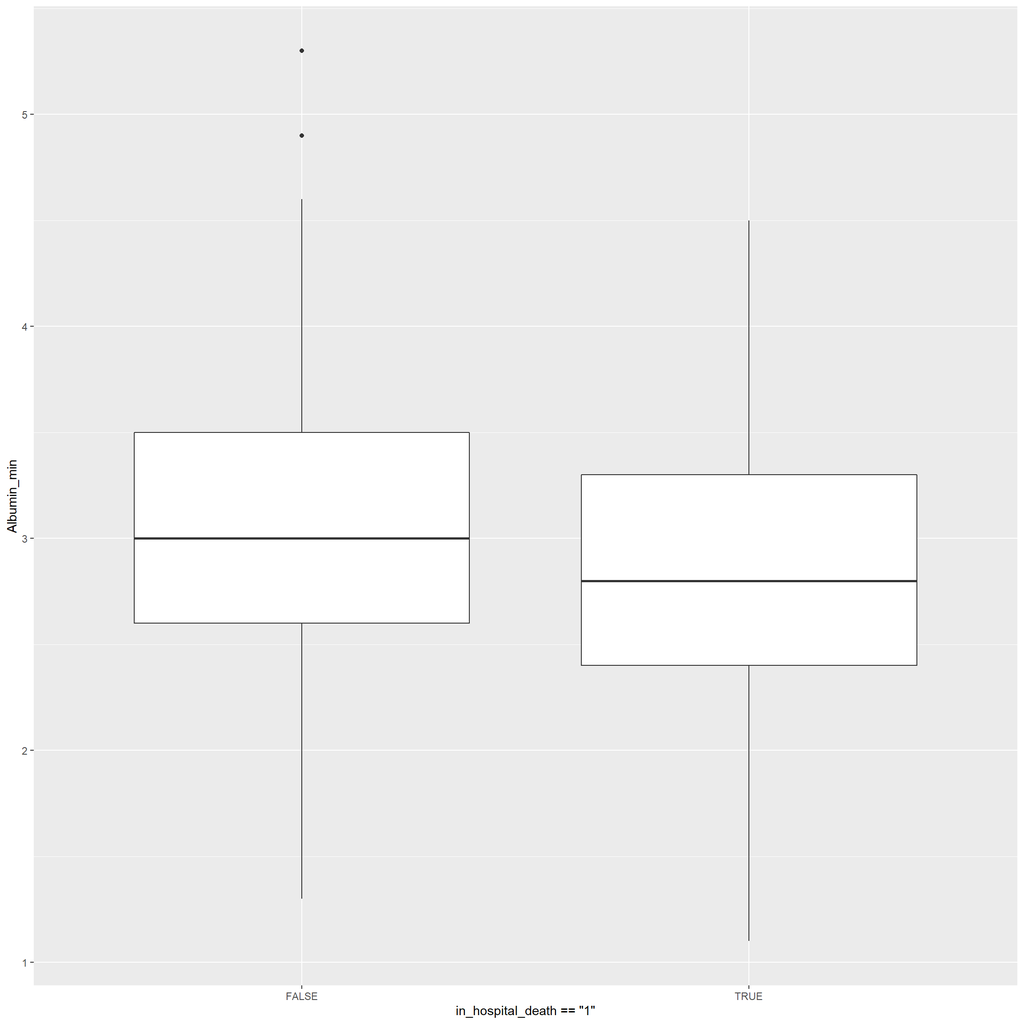

```r
# Basic EDA for each variable
library(ggplot2)
# Patients who died had lower albumin
ggplot(data=icu_patients_df1, mapping = aes(x = in_hospital_death=="1", y = Albumin_min))+ geom_boxplot()
```

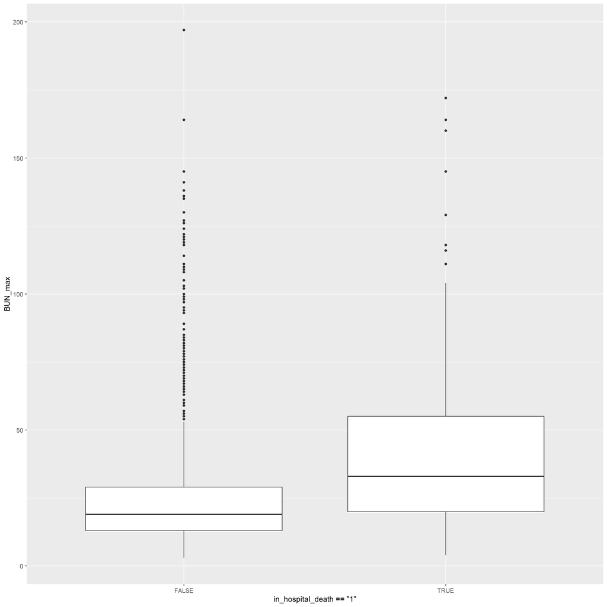

```r
# Patients who died had higher urea
ggplot(data=icu_patients_df1, mapping = aes(x = in_hospital_death=="1", y = BUN_max))+ geom_boxplot()
```

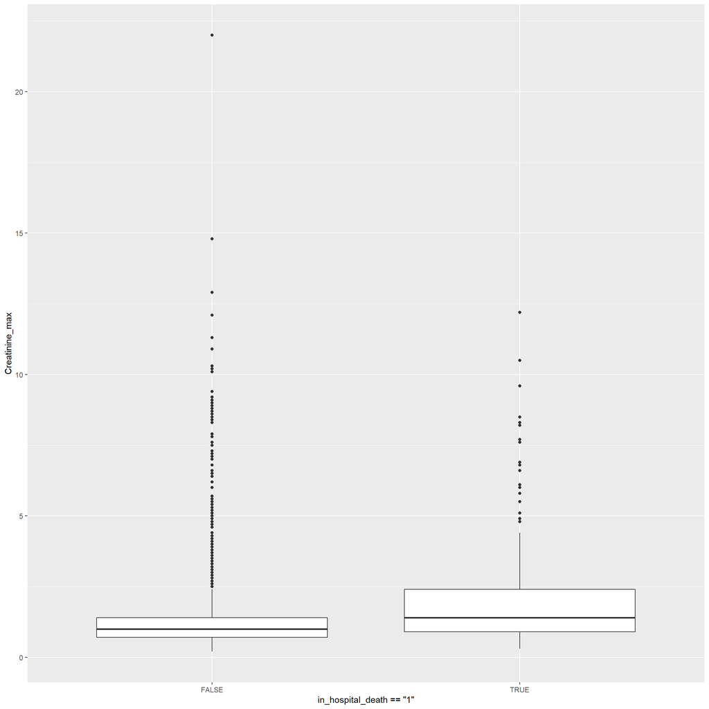

```r
# Patients who died had higher creatinine
ggplot(data=icu_patients_df1, mapping = aes(x = in_hospital_death=="1", y = Creatinine_max))+ geom_boxplot()
```

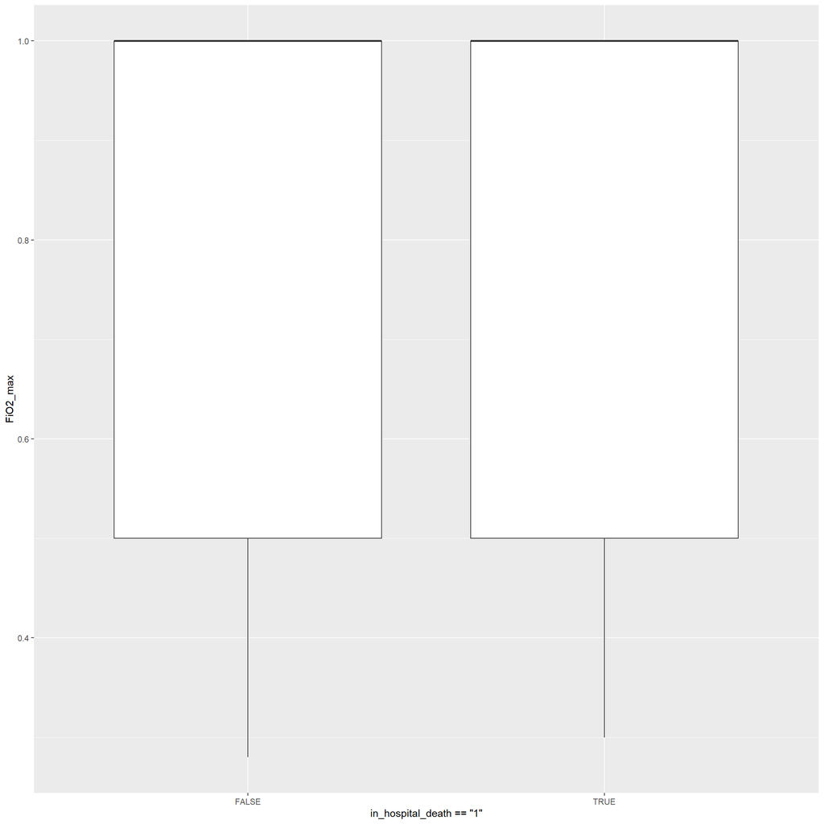

```r
# No difference
ggplot(data=icu_patients_df1, mapping = aes(x = in_hospital_death=="1", y = FiO2_max))+ geom_boxplot()
```

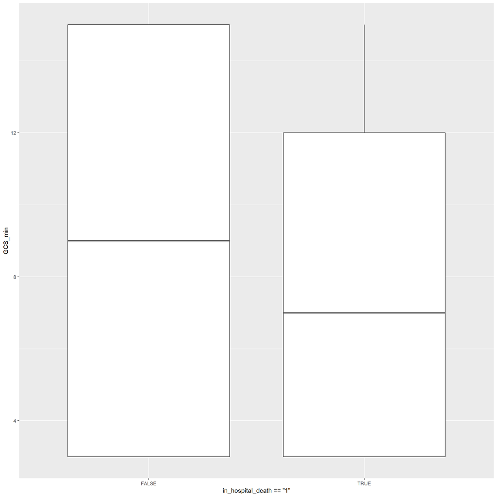

```r
# Patients who died had lower GCS
ggplot(data=icu_patients_df1, mapping = aes(x = in_hospital_death=="1", y = GCS_min))+ geom_boxplot()
```

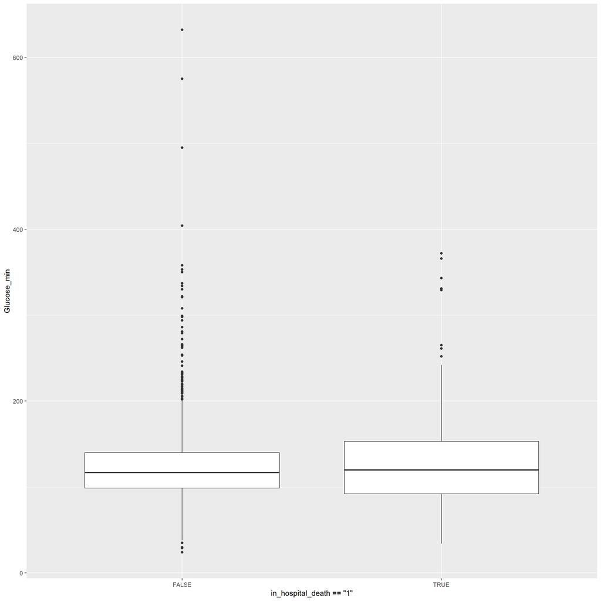

```r
# Little to no difference
ggplot(data=icu_patients_df1, mapping = aes(x = in_hospital_death=="1", y = Glucose_min))+ geom_boxplot()
```

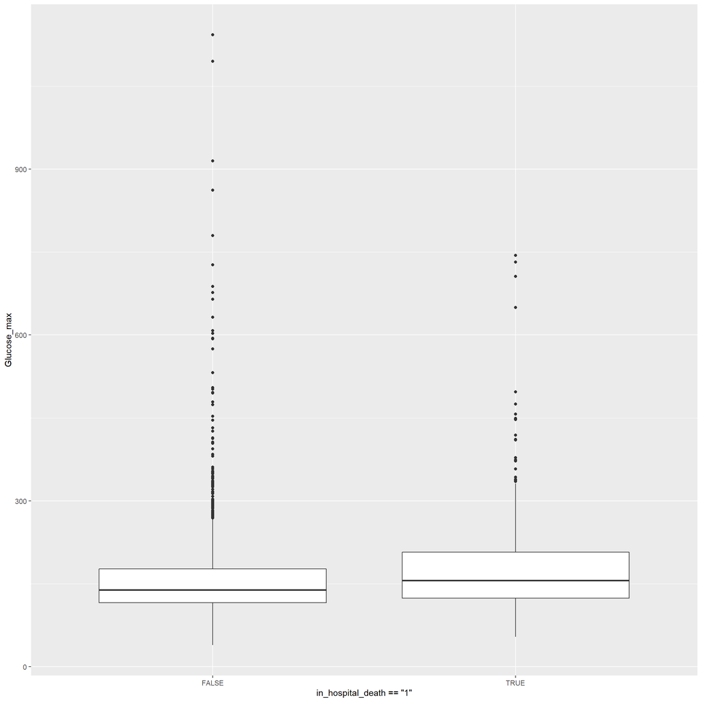

```r
ggplot(data=icu_patients_df1, mapping = aes(x = in_hospital_death=="1", y = Glucose_max))+ geom_boxplot()
```

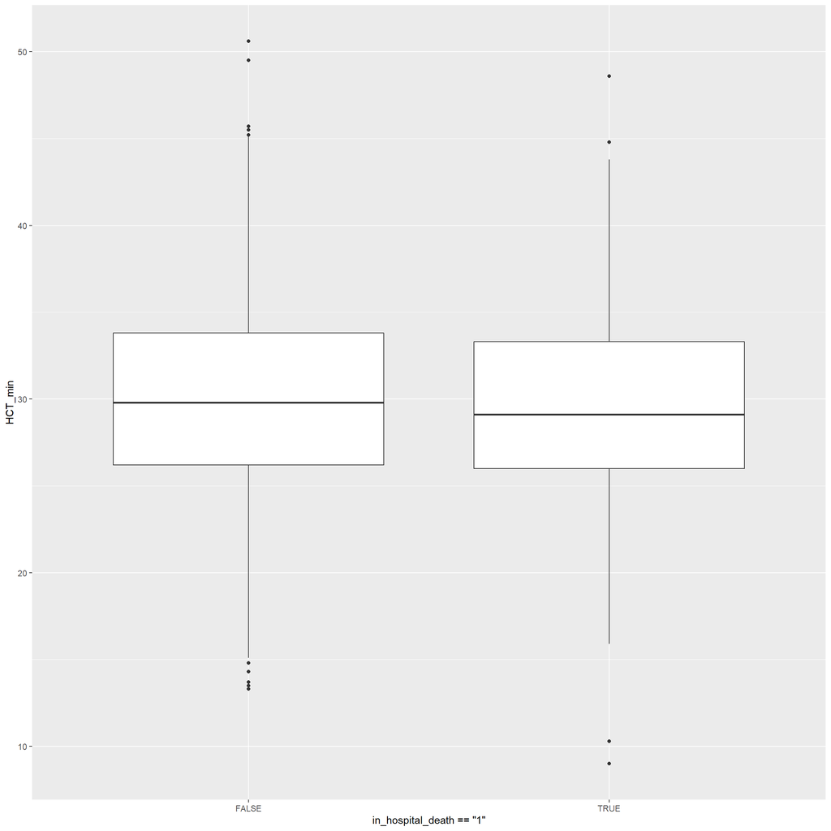

```r
# Patients who died had slightly lower HCT
ggplot(data=icu_patients_df1, mapping = aes(x = in_hospital_death=="1", y = HCT_min))+ geom_boxplot()
```

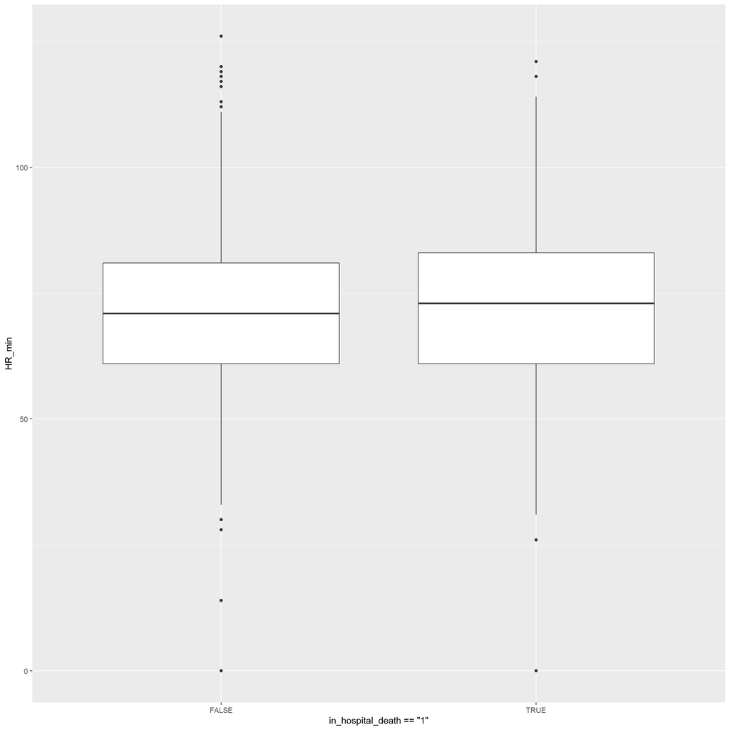

```r
# Patients who died had slightly higher HR_min and HR_max
ggplot(data=icu_patients_df1, mapping = aes(x = in_hospital_death=="1", y = HR_min))+ geom_boxplot()
```

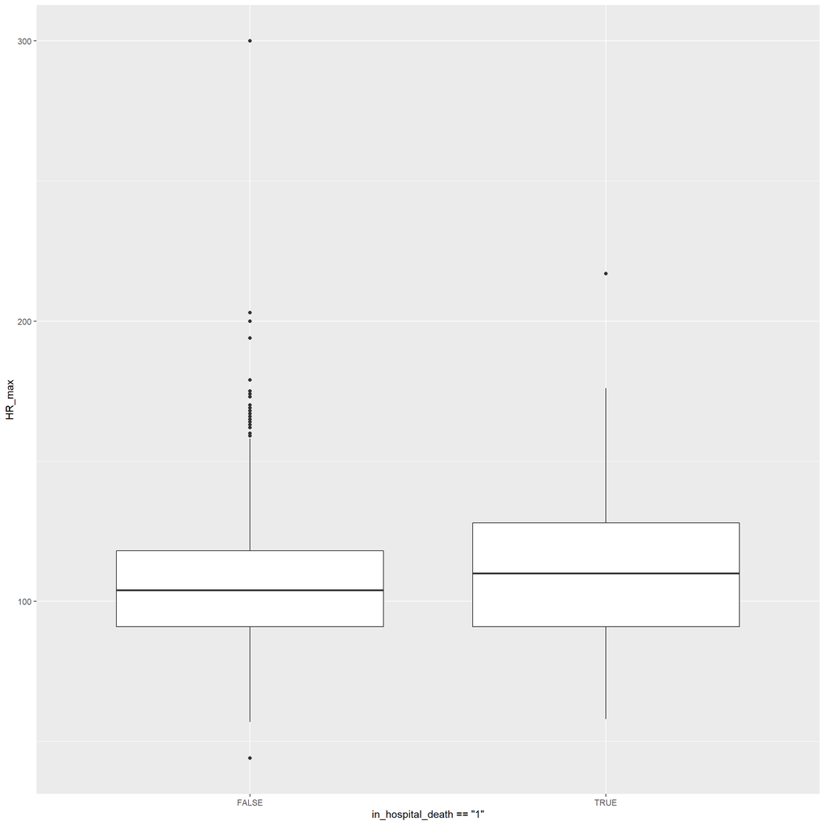

```r
ggplot(data=icu_patients_df1, mapping = aes(x = in_hospital_death=="1", y = HR_max))+ geom_boxplot()
```

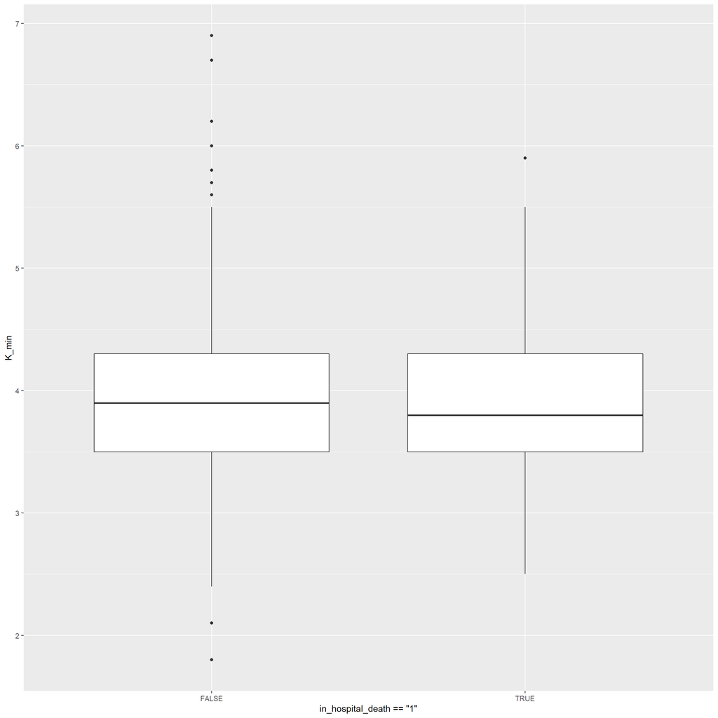

```r
# Little to no difference
ggplot(data=icu_patients_df1, mapping = aes(x = in_hospital_death=="1", y = K_min))+ geom_boxplot()
```

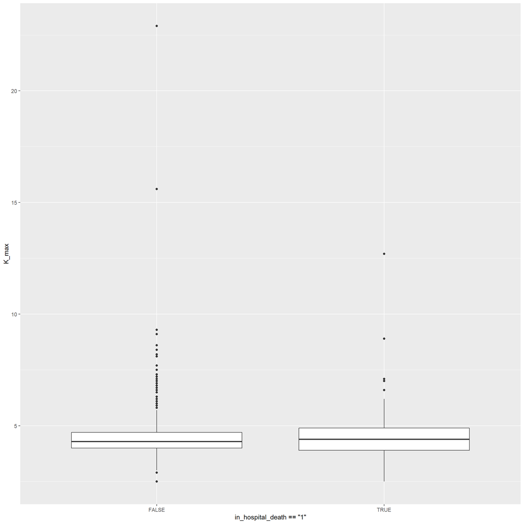

```r
ggplot(data=icu_patients_df1, mapping = aes(x = in_hospital_death=="1", y = K_max))+ geom_boxplot()
```

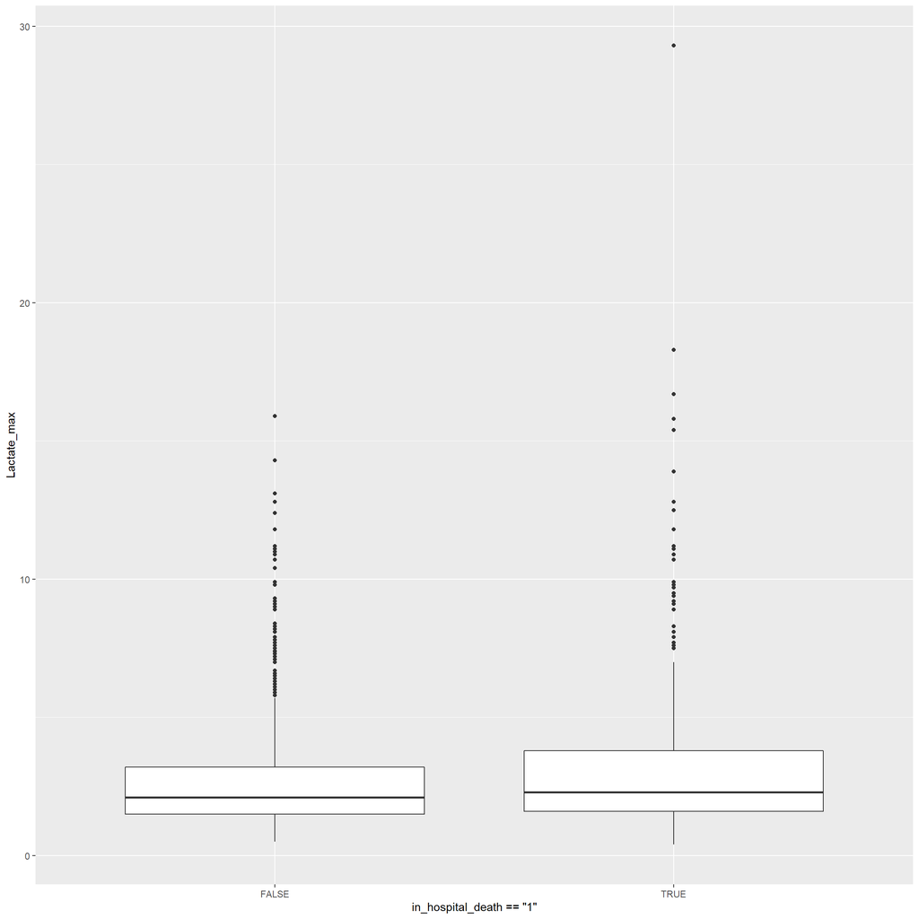

```r
# Patients who died had slightly higher lactate
ggplot(data=icu_patients_df1, mapping = aes(x = in_hospital_death=="1", y = Lactate_max))+ geom_boxplot()
```

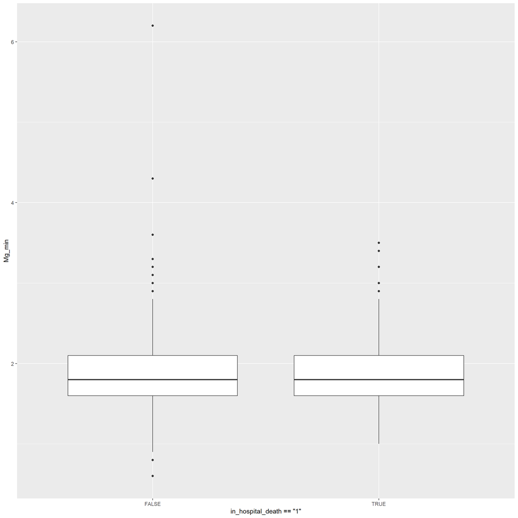

```r
# No difference
ggplot(data=icu_patients_df1, mapping = aes(x = in_hospital_death=="1", y = Mg_min))+ geom_boxplot()
```

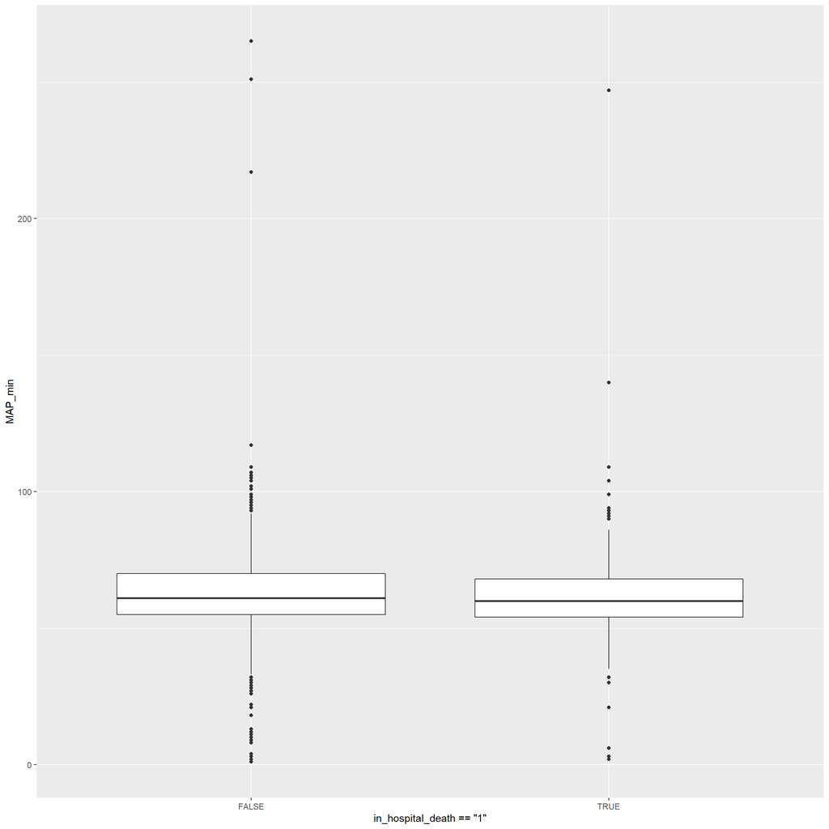

```r
# No difference
ggplot(data=icu_patients_df1, mapping = aes(x = in_hospital_death=="1", y = MAP_min))+ geom_boxplot()
```

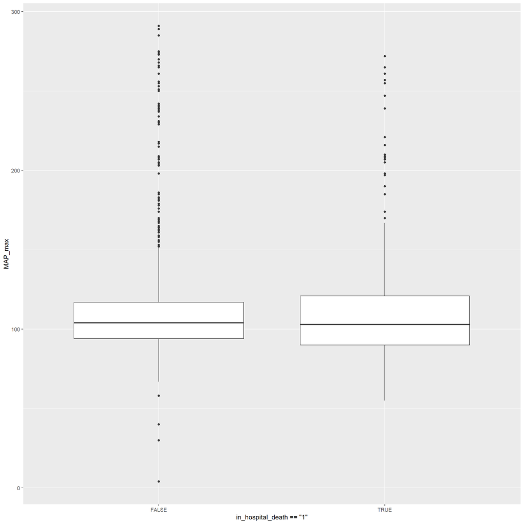

```r
ggplot(data=icu_patients_df1, mapping = aes(x = in_hospital_death=="1", y = MAP_max))+ geom_boxplot()
```

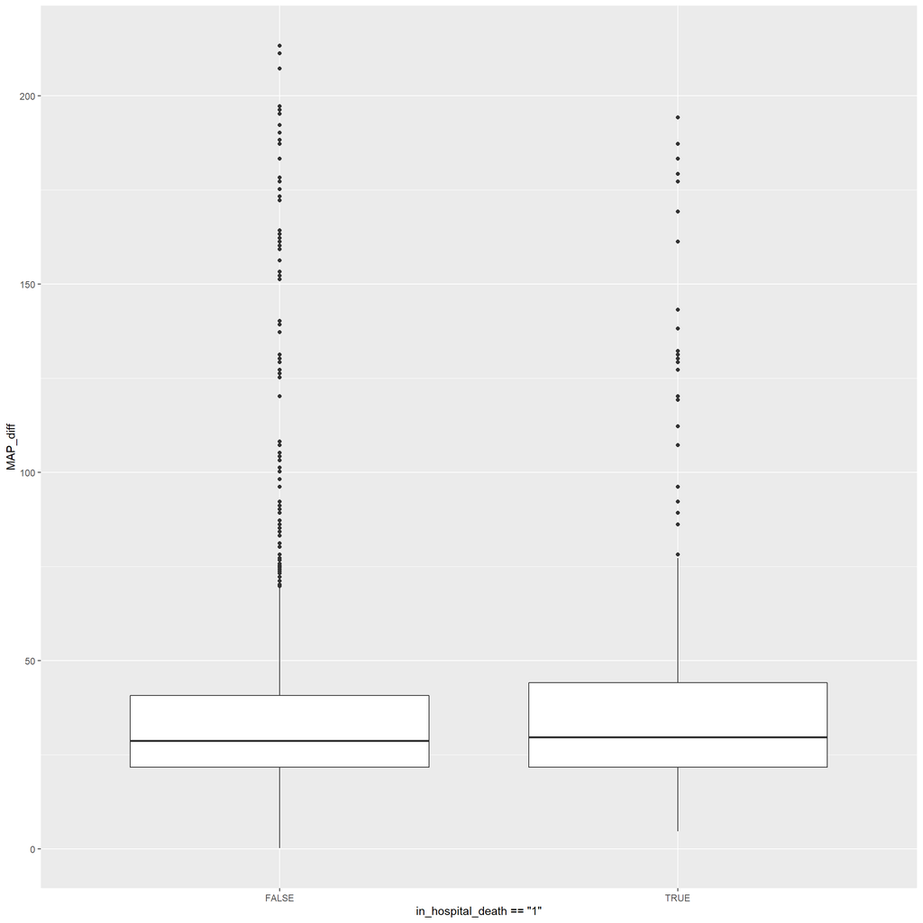

```r
ggplot(data=icu_patients_df1, mapping = aes(x = in_hospital_death=="1", y = MAP_diff))+ geom_boxplot()
```

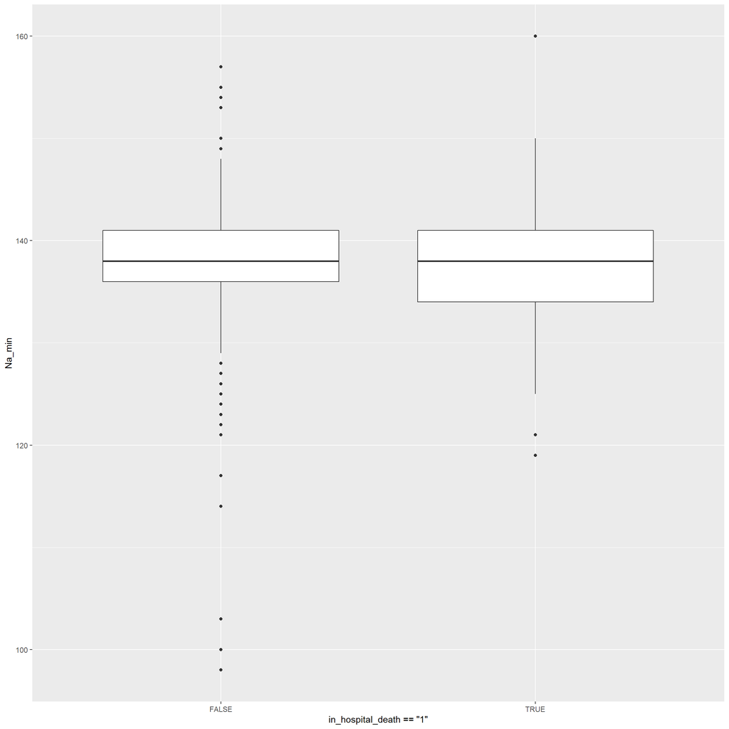

```r
# MechVent row was deleted from the data
# ggplot(data=icu_patients_df1, mapping = aes(x = in_hospital_death=="1", y = MechVent))+ geom_boxplot()

# No difference
ggplot(data=icu_patients_df1, mapping = aes(x = in_hospital_death=="1", y = Na_min))+ geom_boxplot()
```

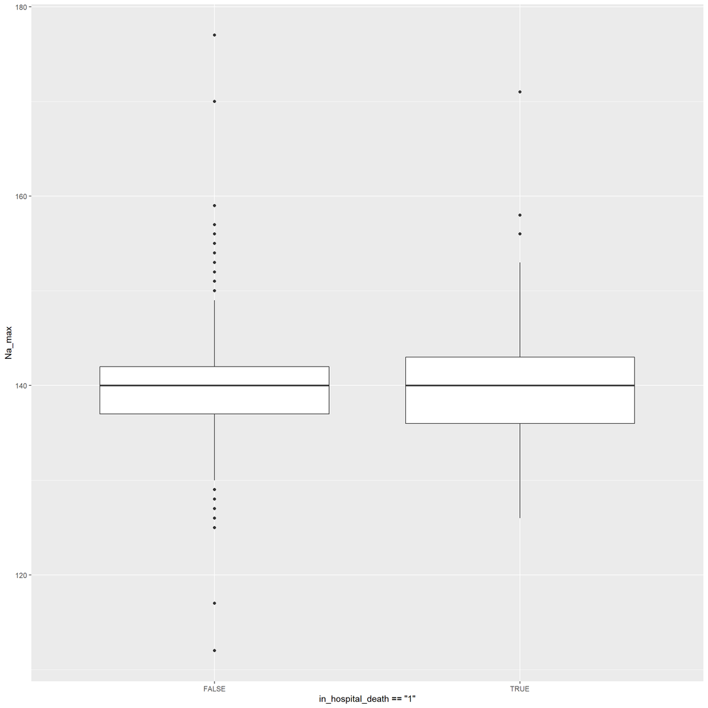

```r
ggplot(data=icu_patients_df1, mapping = aes(x = in_hospital_death=="1", y = Na_max))+ geom_boxplot()
```

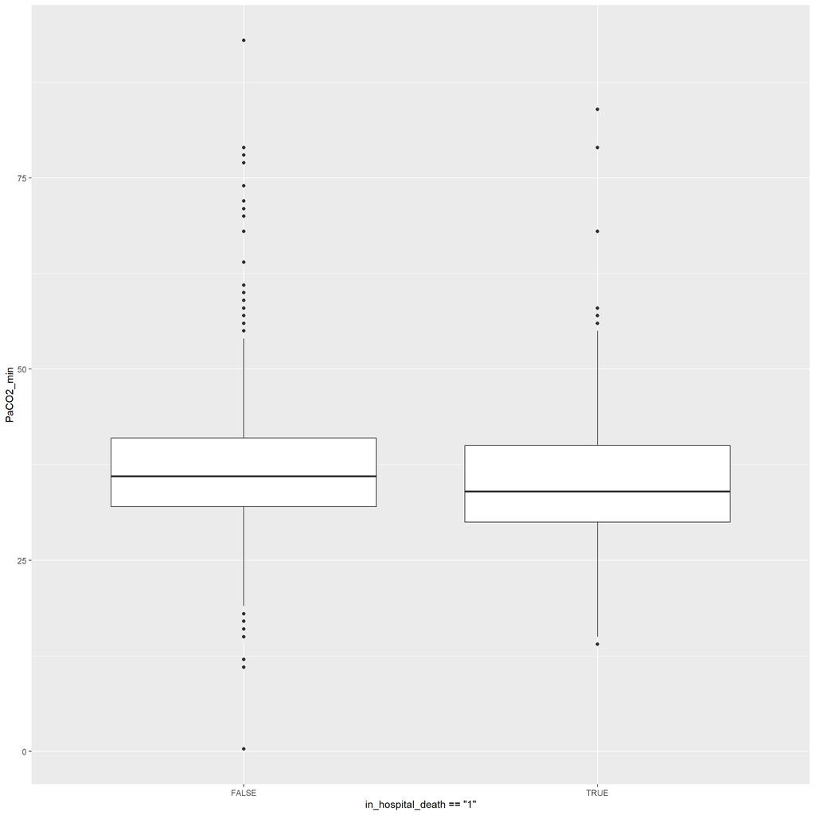

```r
# No difference
ggplot(data=icu_patients_df1, mapping = aes(x = in_hospital_death=="1", y = PaCO2_min))+ geom_boxplot()
```

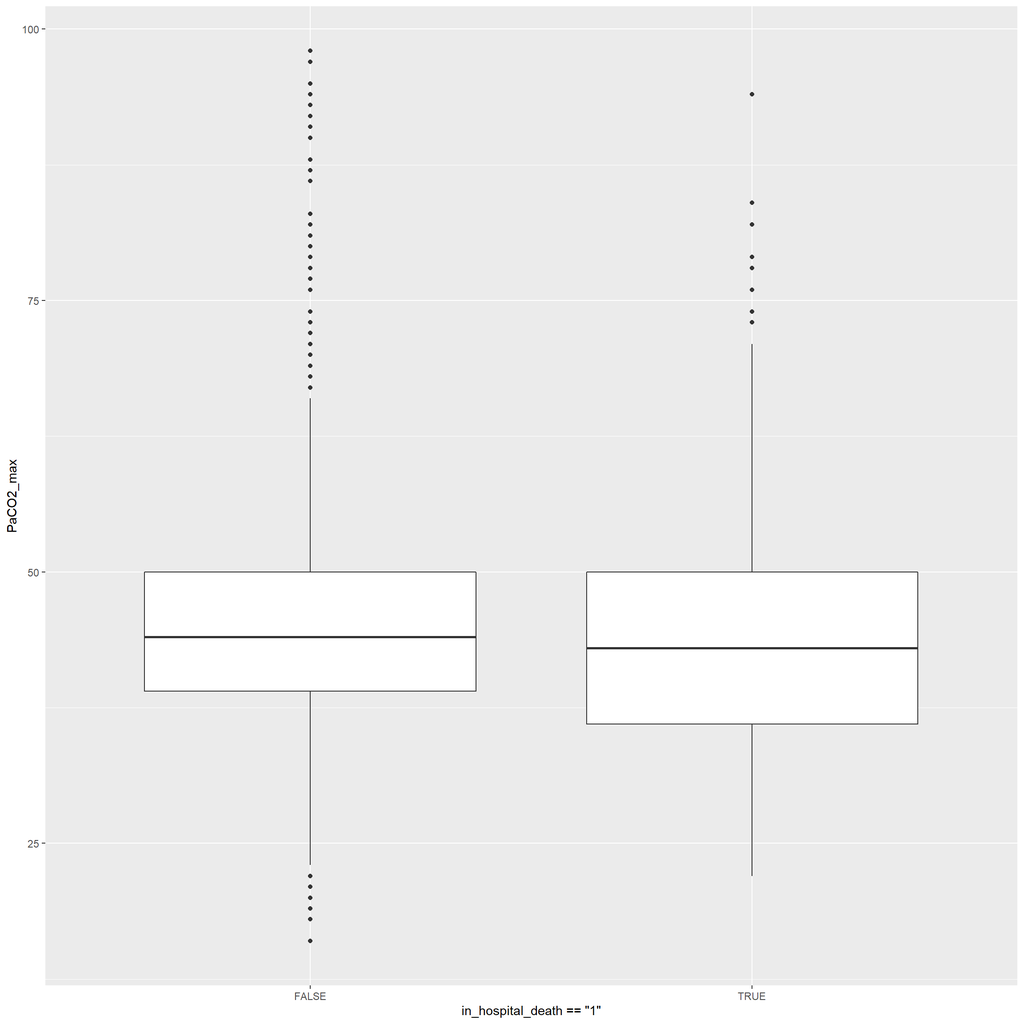

```r
ggplot(data=icu_patients_df1, mapping = aes(x = in_hospital_death=="1", y = PaCO2_max))+ geom_boxplot()
```

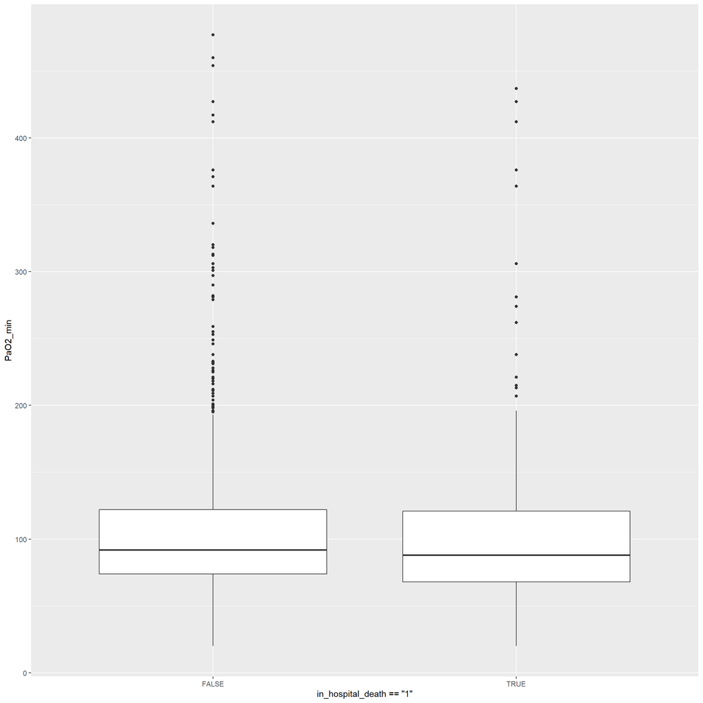

```r
# No difference
ggplot(data=icu_patients_df1, mapping = aes(x = in_hospital_death=="1", y = PaO2_min))+ geom_boxplot()
```

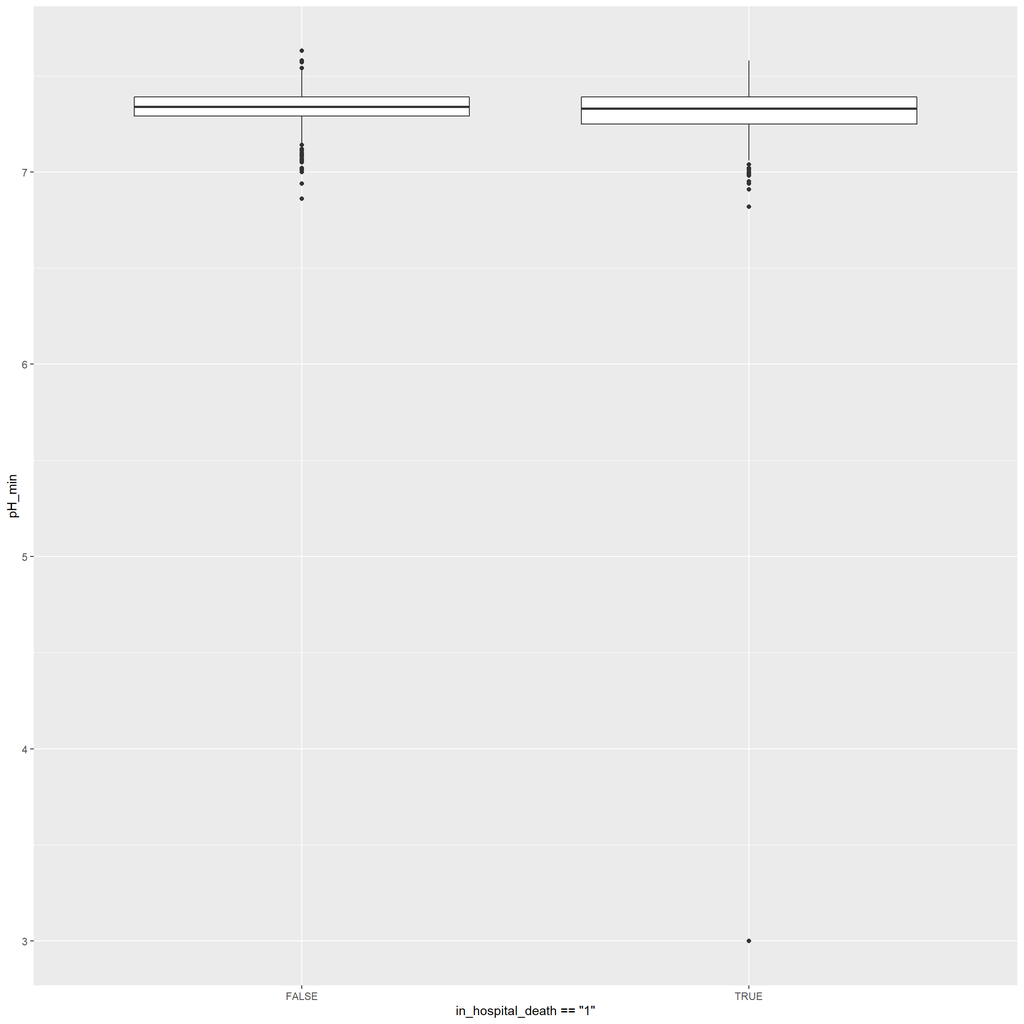

```r
# No difference
ggplot(data=icu_patients_df1, mapping = aes(x = in_hospital_death=="1", y = pH_min))+ geom_boxplot()
```

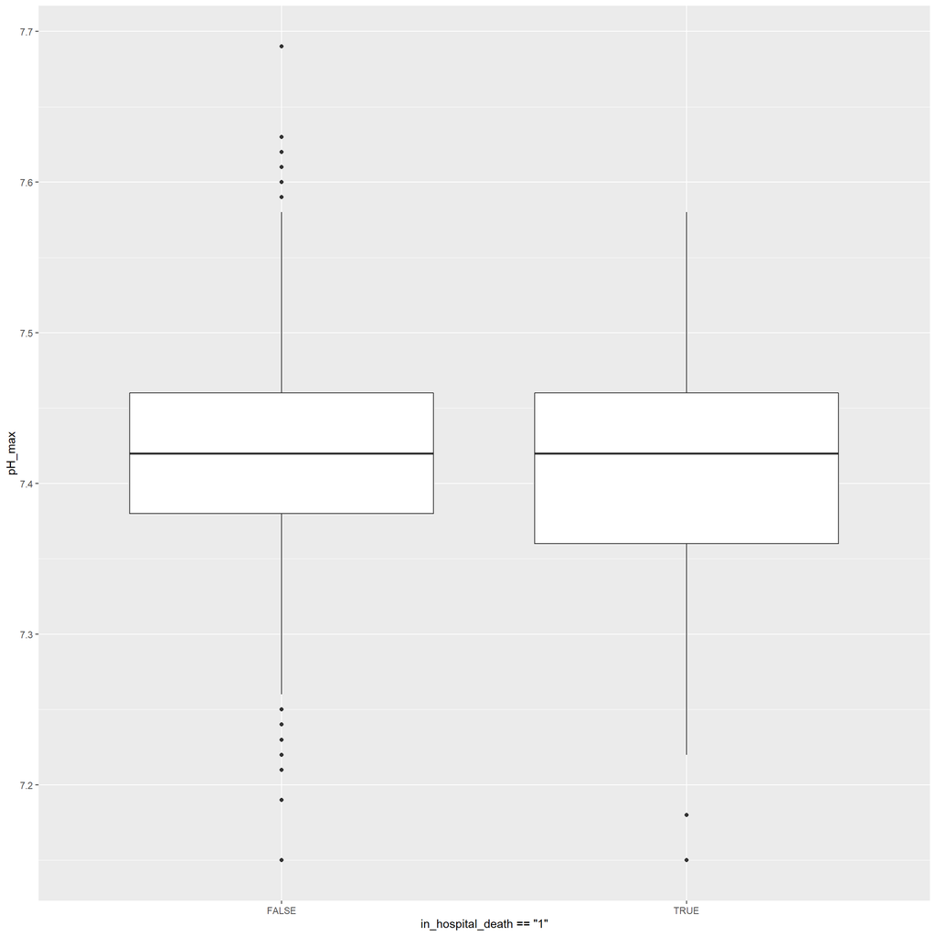

```r
ggplot(data=icu_patients_df1, mapping = aes(x = in_hospital_death=="1", y = pH_max))+ geom_boxplot()
```

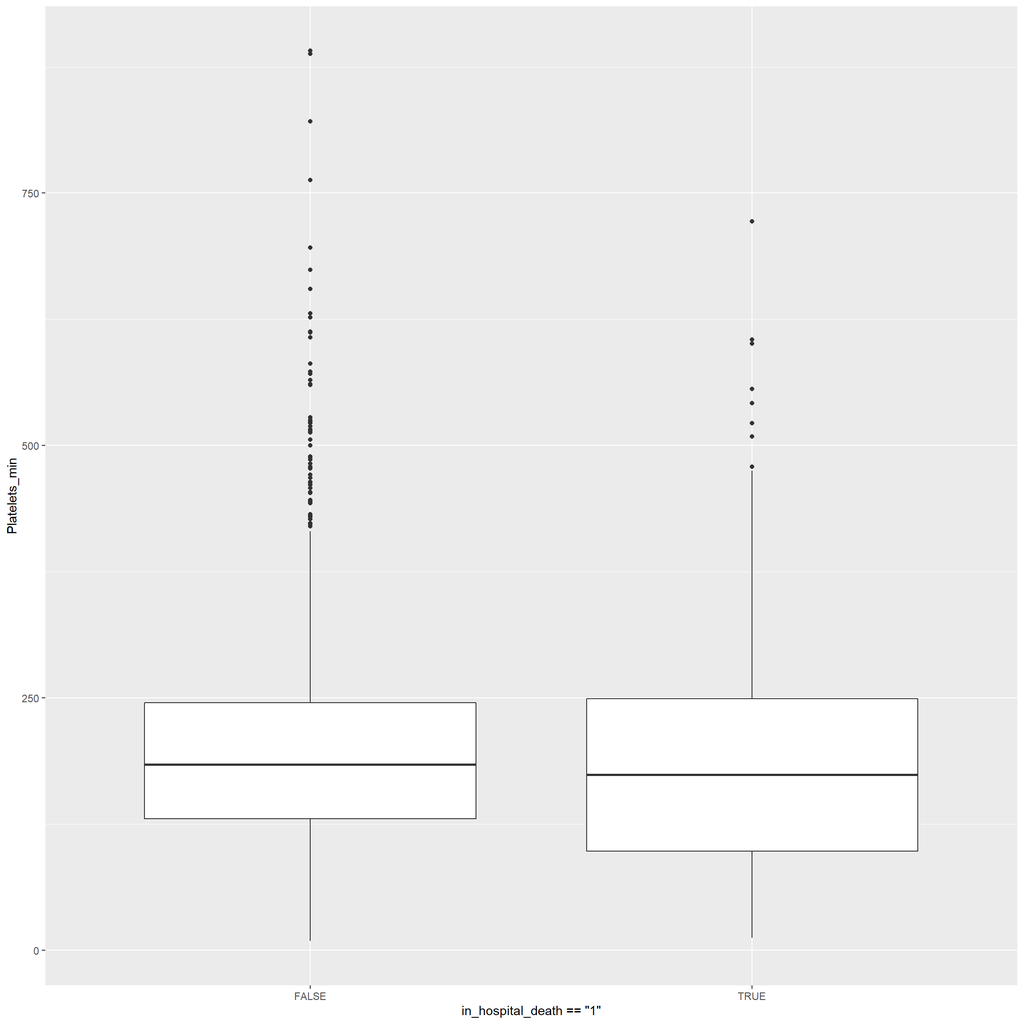

```r
# No difference
ggplot(data=icu_patients_df1, mapping = aes(x = in_hospital_death=="1", y = Platelets_min))+ geom_boxplot()
```

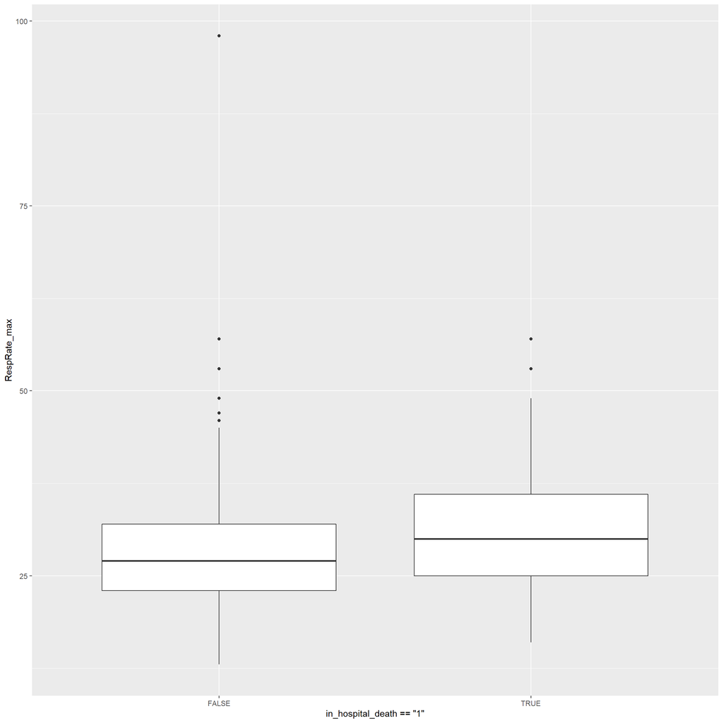

```r
# Patients who died had higher RR
ggplot(data=icu_patients_df1, mapping = aes(x = in_hospital_death=="1", y = RespRate_max))+ geom_boxplot()
```

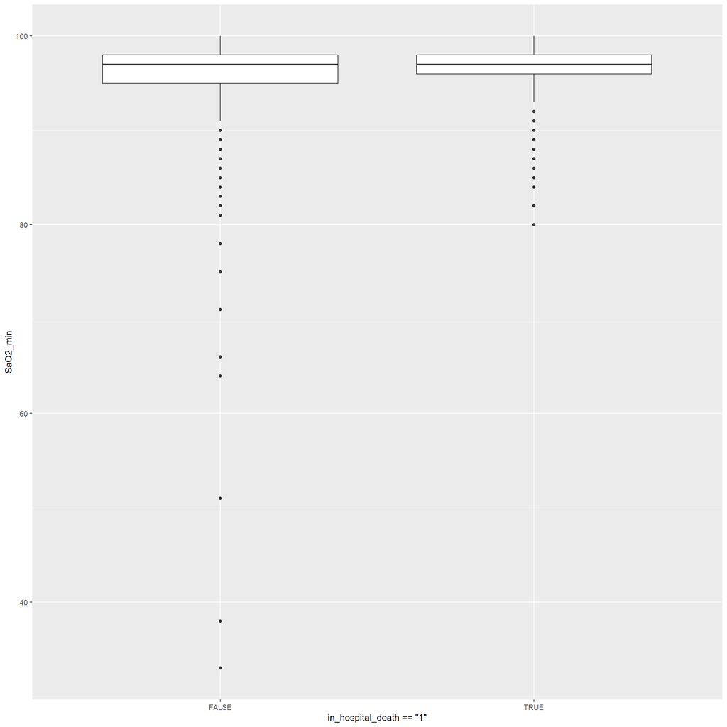

```r
# More outliers in patients who survived with low saturations
ggplot(data=icu_patients_df1, mapping = aes(x = in_hospital_death=="1", y = SaO2_min))+ geom_boxplot()
```

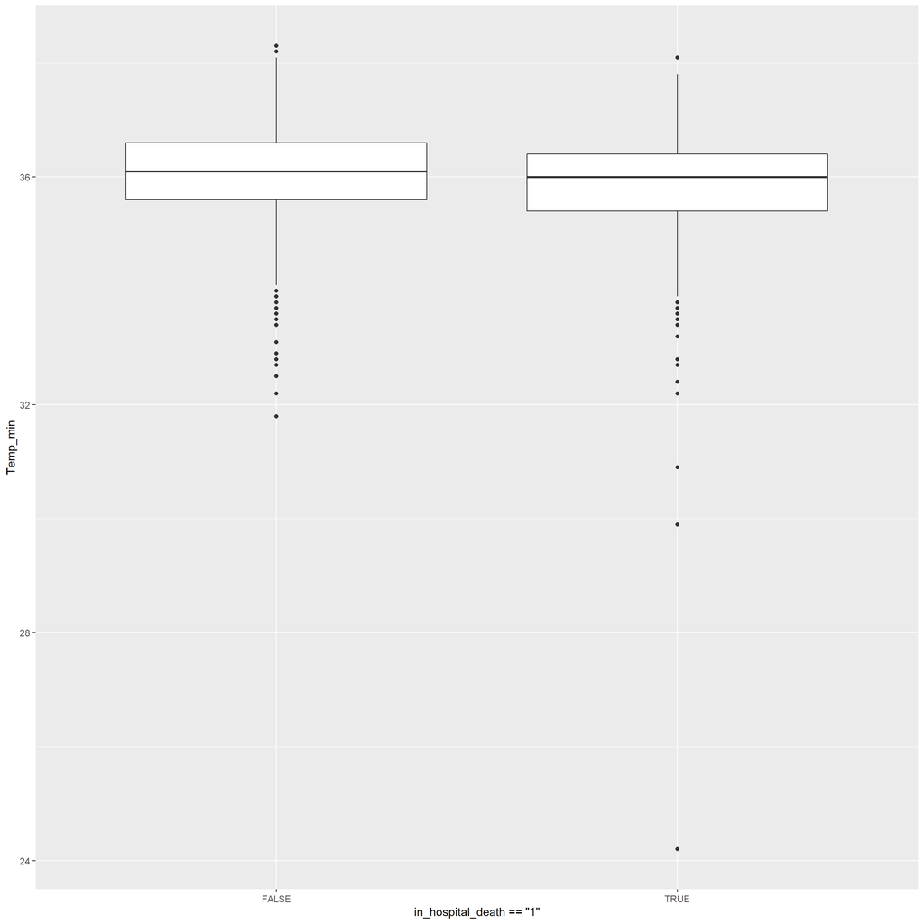

```r
# Patients who died had slightly lower tempeatures
ggplot(data=icu_patients_df1, mapping = aes(x = in_hospital_death=="1", y = Temp_min))+ geom_boxplot()
```

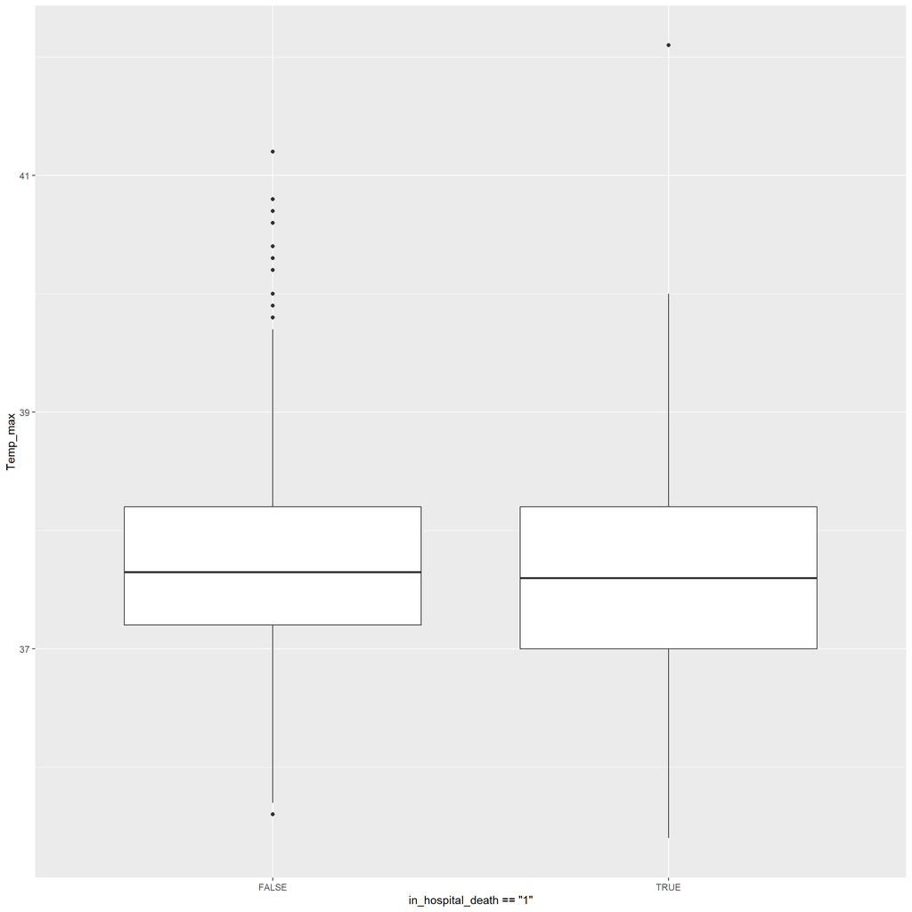

```r
ggplot(data=icu_patients_df1, mapping = aes(x = in_hospital_death=="1", y = Temp_max))+ geom_boxplot()
```

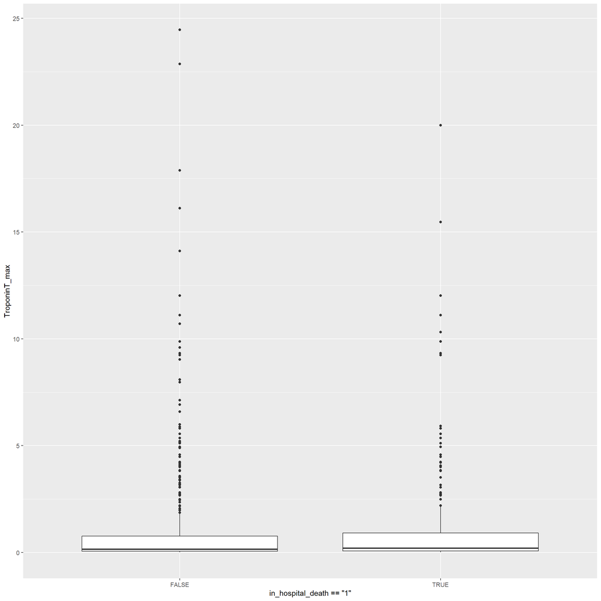

```r
# Patients who died possibly slightly higher tropT
ggplot(data=icu_patients_df1, mapping = aes(x = in_hospital_death=="1", y = TroponinT_max))+ geom_boxplot()
```